# UNIT11A：簡單線性回歸 Simple Linear Regression

中山大學管理學院 卓雍然

2019-11-20 00:06:06

```r
pacman::p_load(MASS,ggplot2, ggpubr, dplyr, plotly)
```

批發商資料集

```r
W = read.csv('data/wholesales.csv')
W$Channel = factor( paste0("Ch",W$Channel) )
W$Region = factor( paste0("Reg",W$Region) )
W[3:8] = lapply(W[3:8], log, base=10)
```

### [A] 用R做線性回歸

- `lm` : 方法
- `md` : 模型
- `Milk` : 目標變數 Response, Dependent Variable (DV)
- `Grocery` : 預測變數 Predictor, Independent Variable (IV)
- `W` : 資料

```r
md = lm(Milk ~ Grocery, W)
```

```r
names(md)
```

```
 [1] "coefficients"  "residuals"     "effects"       "rank"
 [5] "fitted.values" "assign"        "qr"            "df.residual"
 [9] "xlevels"       "call"          "terms"         "model"
```

### [B] 理論 vs 實證模型

- 理論模型：$y_i = \beta_0 + \beta_1 x_i + \epsilon_i, \; \epsilon \in i.i.d. Normal Dist.$
  - $\beta_0$, $beta_1$ - 係數
  - $y_i$ - 目標變數
  - $x_i$ - 預測變數
  - $\epsilon_i$ - 誤差
- 估計模型：$\hat{y}_i = b_0 + b_1 x_i$
  - `md$coefficient` : $b_0$, $b_1$ - 係數估計值
  - `md$fitted.value` : $\hat{y}_i$ - 目標變數估計值
  - `md$residuals` : $e_i = y - \hat{y}$ - 殘差

```r
y = W$Milk
x = W$Grocery
b0 = md$coef[1]
b1 = md$coef[2]
yhat = b0 + b1 * x
er = y - yhat
```

```r
range(yhat - md$fitted.values)
```

```
[1] -0.0000000000000015543  0.0000000000000257572
```

```r
range(er - md$residuals)
```

```
[1] -0.0000000000000255906  0.0000000000000015543
```

### [C] 畫出回歸線

$$Milk_i = b_0 + b_1 Grocery_i$$

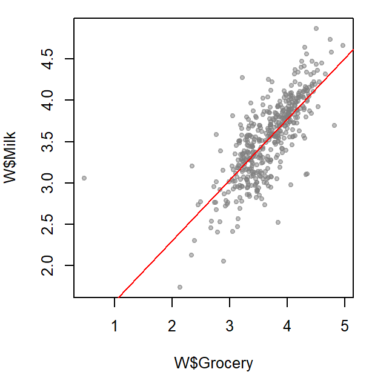

```r
par(cex=0.8, mar=c(4,4,1,1))
plot(W$Grocery, W$Milk, pch=20, col="#80808080")
abline(b0, b1, col='red')
```

```r
ggplot(aes(Grocery, Milk), data=W) +
  geom_point(alpha=0.4, size=0.8) +
  geom_smooth(method="lm", level=0.95, col="red", lwd=0.2) -> p
ggplotly(p)
```

[interactive chart not shown]

🗿 : 為什麼大部分的資料點都沒有落在95%信心區間呢？

💡 : 模型估計的是$y$的平均值($\bar{Y}|x$)、而不是$y$本身！

### [D] Model Summary 功能

```r
summary(md)
```

```
Call:
lm(formula = Milk ~ Grocery, data = W)

Residuals:
    Min      1Q  Median      3Q     Max
-1.1371 -0.1875  0.0219  0.1593  1.8732

Coefficients:
            Estimate Std. Error t value             Pr(>|t|)
(Intercept)   0.8318     0.1115    7.46     0.00000000000047 ***
Grocery       0.7352     0.0301   24.39 < 0.0000000000000002 ***
---
Signif. codes:  0 '***' 0.001 '**' 0.01 '*' 0.05 '.' 0.1 ' ' 1

Residual standard error: 0.306 on 438 degrees of freedom
Multiple R-squared:  0.576, Adjusted R-squared:  0.575
F-statistic:  595 on 1 and 438 DF,  p-value: <0.0000000000000002
```

- $\hat{y}_i = 0.8318 + 0.7352 x_i$
  - $b_0=0.8318$ : $x=0$ 時 $y$ 的估計值
  - $b_1=0.7352$ : $x$ 對 $y$ 的平均邊際效果
- Coefficients:
  - Estimate: 係數估計值
  - Std. Error: 係數估計值的標準差
  - Pr(>|t|): p值 (變數之間沒有關係的機率？)
  - Signif. codes: 顯著水準

💡 : $b_1$ 係數代表平均而言， $x$ 每增加一單位時，$y$ 會增加的數量

##### 係數的分布

[figure not shown]

```r
curve(dnorm(x, 0.7352, 0.0301), -0.1, 1, n=400, xlab=bquote(italic(b[0])),
      main=bquote("The Distribution of Random Variable: " ~ italic(b[0])))
abline(v=qnorm(c(0.025, 0.975),0.7352, 0.0301), col="red")
```

💡 : 係數($b_0, b_1$)也都是隨機變數

### [E] 模擬一組相關的變數 Multivariate Normal Distribution

**參數：平均值向量與變異(共變)矩陣**

```r
mu = c(2,3)                         # mean vector
(Sigma = matrix(c(1,0.5,0.5,1),2))  # variance, covariance matrix
```

```
     [,1] [,2]
[1,]  1.0  0.5
[2,]  0.5  1.0
```

**隨機抽樣 A Random Sample of 20 Points**

```r
set.seed(2); A = mvrnorm(20, mu, Sigma) %>% data.frame
colnames(A) = c("x", "y")
```

**使用樣本建立模型： Models with 1 and 2 Parameters**

- Model-0: $y_i = b_0 + \epsilon_i$
- Model-1: $y_i = b_0 + b_1 x_i + \epsilon_i$

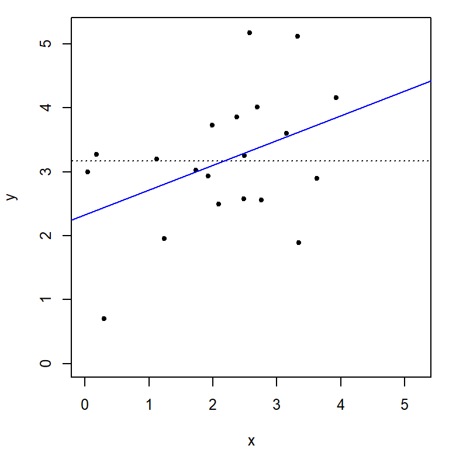

```r
m0 = lm(y ~ 1, A)
m2 = lm(y ~ x, A)
plot(A,pch=20,xlim=c(0,5.2),ylim=c(0,5.2))
abline(h=coef(m0), lty=3)
abline(coef(m2)[1], coef(m2)[2], col="blue")
```

💡 : 要產生一組$K$個相關的變數需要一個長度為$K$的平均值向量，和一個維度是$K \times K$的變異(共變)矩陣

### [F] 變異數分解 Decomposition of Variance

- SST (Total Sum of Sq.) = $\Sigma_i(y_i - \bar{y}_i)^2$
- SSE (Error Sum of Sq.) = $\Sigma_i(y_i - \hat{y_i})^2 = \Sigma_i e_i^2$
- SSR (Regression Sum of Sq.) = SST - SSE
- $R^2$ (判定係數 Determination Coef.) = SSR/SST，模型所能解釋目標變數的變異的能力

```r
SST = sum( (y - mean(y))^2 )            # Total Sum of Sq.
SSE = sum( (y - md$fitted.values)^2 )   # Error Sum of Sq.
SSR = SST - SSE                         # Regression Sum of sql
R2 = SSR/SST    # The Propotion of Variance explained by Regressor
c(SST=SST, SSE=SSE, SSR=SSR, R2=R2)
```

```
     SST      SSE      SSR       R2
96.82289 41.06697 55.75591  0.57585
```

```r
cor(md$fitted.values, md$residuals)
```

```
[1] -0.00000000000000012156
```

💡 : 因為 Cov($\hat{y}$, $e$) = 0， 所以 Var($y$) = Var($\hat{y}+e$) = Var($\hat{y}$) + Var($e$)

### [G] 類別自變數 和 變異數分析 Analysis of Variance (ANOVA)

`lm()`裡面類別和連續預測變數的寫法是一樣的，做模型時，一個有k個分類的類別變數會產生(k-1)個虛擬變數(Dummy Variables) …

```r
lm(Grocery ~ Region, W) %>% summary
```

```
Call:
lm(formula = Grocery ~ Region, data = W)

Residuals:
   Min     1Q Median     3Q    Max
-3.181 -0.327  0.008  0.356  1.310

Coefficients:
            Estimate Std. Error t value            Pr(>|t|)
(Intercept)   3.6297     0.0552   65.79 <0.0000000000000002 ***
RegionReg2    0.1499     0.0896    1.67               0.095 .
RegionReg3    0.0282     0.0615    0.46               0.647
---
Signif. codes:  0 '***' 0.001 '**' 0.01 '*' 0.05 '.' 0.1 ' ' 1

Residual standard error: 0.484 on 437 degrees of freedom
Multiple R-squared:  0.00707,   Adjusted R-squared:  0.00252
F-statistic: 1.56 on 2 and 437 DF,  p-value: 0.212
```

💡 : The idea of Dummy Variables

- $\hat{y}_i = b_0 + b_1 Reg2 + b_2 Reg3$
- $\hat{y}_i = 3.6297 + 0.1499 \times Reg2 + 0.0282 \times Reg3$
- $\hat{y}_{reg1} = 3.6297$
- $\hat{y}_{reg2} = 3.6297 + 0.1499$
- $\hat{y}_{reg3} = 3.6297 + 0.0282$

##### ANOVA 檢定各分群的平均值是否相等

- 虛無假設： $H_0 : u_0 = u_1 = u_2 = ...$ 分群的平均值都相等

```r
aov(Grocery ~ Region, data = W) %>% summary
```

```
             Df Sum Sq Mean Sq F value Pr(>F)
Region        2    0.7   0.365    1.56   0.21
Residuals   437  102.4   0.234
```

$p=0.21 > 0.05$ 不能拒絕各區域(`Region`)雜貨購貨量(`Grocery`)的平均值之間沒有差異的虛無假設

💡 : 其實做Simple Regression和ANOVA檢定之前分別都有一些前提假設和殘差分析需要確認， 詳情請看[教科書](https://cran.r-project.org/web/packages/IPSUR/vignettes/IPSUR.pdf)

##### Kruskal-Wallis 檢定

當某些前提假設不能成立時，我們可以借助無母數(non-parametric)的檢定方法

```r
df = ToothGrowth
head(df)
```

```
   len supp dose
1  4.2   VC  0.5
2 11.5   VC  0.5
3  7.3   VC  0.5
4  5.8   VC  0.5
5  6.4   VC  0.5
6 10.0   VC  0.5
```

[`ggpubr`套件](http://www.sthda.com/english/articles/24-ggpubr-publication-ready-plots/) 裡面有自動化工具可以做整體和個別(事後Post-Hoc)檢定並畫出圖形

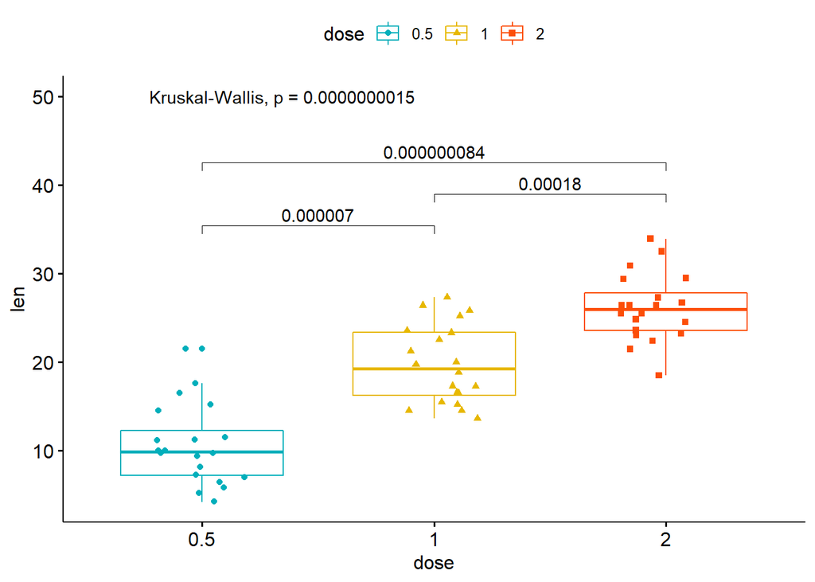

```r
compare <- list( c("0.5", "1"), c("1", "2"), c("0.5", "2") )
ggboxplot(
  df, x = "dose", y = "len",
  color = "dose", palette =c("#00AFBB", "#E7B800", "#FC4E07"),
  add = "jitter", shape = "dose") +
  stat_compare_means(comparisons = compare) +
  stat_compare_means(label.y = 50)
```

💡 : 如果組間平均值的檢定顯著，通常我們需要進一步做事後(Post-Hoc)檢定，藉以比較各分組兩兩之間的平均值。